# Dissertation Analyses

Author: Marwin M I B Carmo

2022-08-20

#Summary

**Step 1** performs basic descriptive statistics at item level.

**Step 2** examines item properties according to non-parametric item response theory (IRT) requirements (Mokken Scaling Analysis; MSA).

**Step 4** examines the structure of the item set according to factor analysis (exploratory and confirmatory).

**Step 5** examines scale reliability and item properties for unidimensional item sets according to Classical Test Theory.

Finally, **step 6** computes total scores and score statistics for each unidimensional item set, and displays distributions as histograms.

```r
sel.data <- raw.data |>
  # fill idade
  dplyr::group_by(record_id) |>
  tidyr::fill(nome, .direction = "down") |>
  tidyr::fill(idade, .direction = "down") |>
  tidyr::fill(cpf, .direction = "down") |>
  dplyr::ungroup() |>
  dplyr::filter(!is.na(escala_breve_de_aceitao_do_sono_complete)) |>
  dplyr::select(record_id, nome, cpf, redcap_event_name, sexo, idade, igi_escore, ehad_depressao_escore,
                ehad_ansiedade_escore, aaq_score, dbas_score, contains("spaq_"), ebas_1:ebas_6) |>
  dplyr::filter(redcap_event_name == "elegibilidade_arm_1") |>
  dplyr::filter(!stringr::str_detect(nome, stringr::regex("teste", ignore_case = TRUE))) |>
  # reverse score spaq
  dplyr::mutate(across(spaq_5:spaq_8, ~ 6 - .x)) %>%
  dplyr::mutate(spaq_score = dplyr::select(., spaq_1:spaq_8) %>% rowSums()) %>%
  dplyr::select(-c(spaq_1:spaq_8)) |>
  dplyr::mutate(insonia = dplyr::case_when(cpf %in% gc$cpf ~ 0,
                                         TRUE ~ 1))
ebas <- dplyr::select(sel.data, ebas_1:ebas_6)
```

Sample size: 1677.

Complete cases: 1419

# Step 1: Descriptives

```r
# compute unique levels in data frame
lvls <- unique(unlist(ebas))

# apply the summation per value
freq <- sapply(ebas,
               function(x) table(factor(x, levels = lvls,
                                        ordered = TRUE)))
freqebas <- as.data.frame(freq) |>
  tibble::rownames_to_column() |>
  dplyr::rename("score" = "rowname") |>
  dplyr::arrange(score)
knitr::kable(freqebas)
```

| score | ebas_1 | ebas_2 | ebas_3 | ebas_4 | ebas_5 | ebas_6 |
| --- | --- | --- | --- | --- | --- | --- |
| 1 | 250 | 282 | 399 | 371 | 313 | 302 |
| 2 | 246 | 248 | 114 | 120 | 193 | 134 |
| 3 | 161 | 144 | 102 | 89 | 126 | 78 |
| 4 | 297 | 343 | 249 | 223 | 314 | 209 |
| 5 | 203 | 197 | 193 | 210 | 198 | 168 |
| 6 | 167 | 133 | 173 | 191 | 134 | 184 |
| 7 | 95 | 72 | 189 | 215 | 141 | 344 |

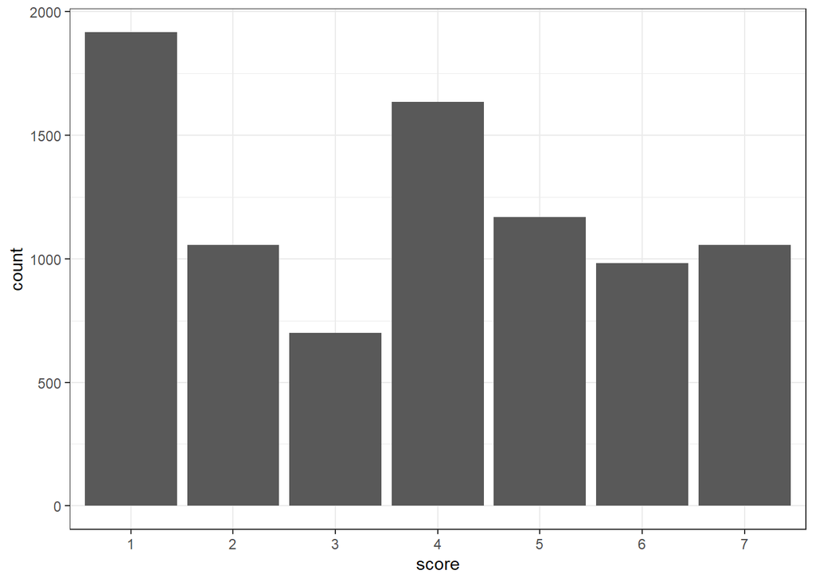

```r
freqebas |>
  tidyr::pivot_longer(cols = dplyr::starts_with("ebas_"), values_to = "count", names_to = "item") |>
  dplyr::with_groups(score, summarise, count = sum(count)) |>
  ggplot(aes(x = score, y = count)) +
  geom_bar(stat = "identity") +
  theme_bw()
```

```r
ebas <- janitor::remove_empty(ebas, "rows")
mydata <- ebas
psych::describe(ebas)
```

```
##        vars    n mean   sd median trimmed  mad min max range  skew kurtosis
## ebas_1    1 1419 3.59 1.86      4    3.53 2.97   1   7     6  0.15    -1.09
## ebas_2    2 1419 3.43 1.80      4    3.35 2.97   1   7     6  0.19    -1.01
## ebas_3    3 1419 3.70 2.16      4    3.63 2.97   1   7     6  0.06    -1.38
## ebas_4    4 1419 3.86 2.19      4    3.82 2.97   1   7     6 -0.04    -1.41
## ebas_5    5 1419 3.60 1.97      4    3.51 2.97   1   7     6  0.15    -1.14
## ebas_6    6 1419 4.22 2.26      4    4.28 2.97   1   7     6 -0.20    -1.43
##          se
## ebas_1 0.05
## ebas_2 0.05
## ebas_3 0.06
## ebas_4 0.06
## ebas_5 0.05
## ebas_6 0.06
```

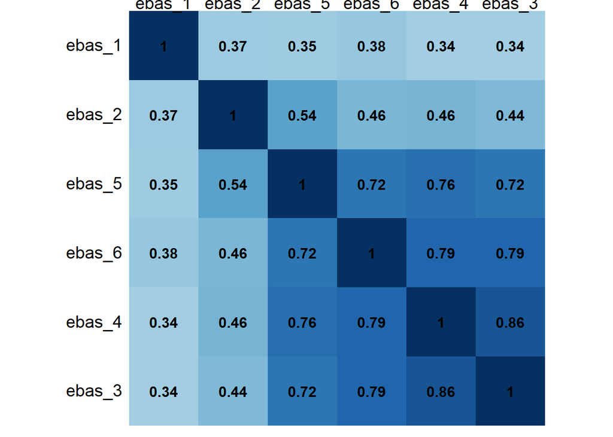

```r
library(corrplot)
ebascor <- cor(ebas)

corrplot(ebascor, method = "shade", shade.col = NA, tl.col = "black", tl.srt = 0, type="full",
          addCoef.col = "black", cl.pos = "n", order = "AOE", tl.cex = 1.2, number.cex=1)
```

```r
d2mydata <- psych::outlier(ebas, cex=.6, bad=3, ylim=c(0,130))
```

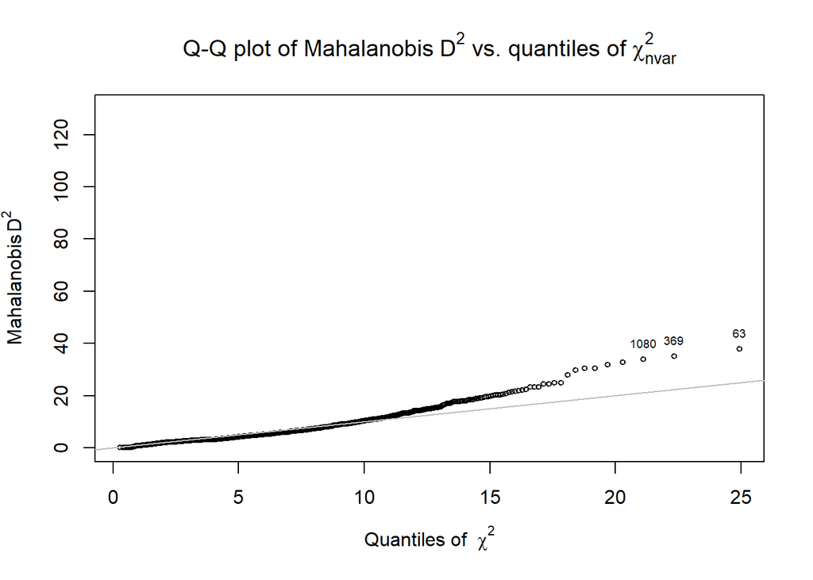

There were 17 respondents with D<sup>2</sup> values with probability values <.001 (considering a chi-squared distribution with df = 6). The maximum D<sup>2</sup> value is 38.06.

## Interpretation

- Are there any out-of-range values? **No**
- Are all response options well-represented in the data? **Yes**
- Are all associations between items positive? **Yes**
- Are there multivariate outliers in the data? **Yes, 17**

# Step 2: Item properties - Mokken Scaling Analysis (MSA)

## Results

The distribution of Guttman errors is shown in Figure 1.

The homogeneity values of all items in the initial item set are showm in Table 1.

To test unidimensionality, the results of an automated item selection procedure (*aisp*) with all items are shown in Table 2.

### (i) Data examination

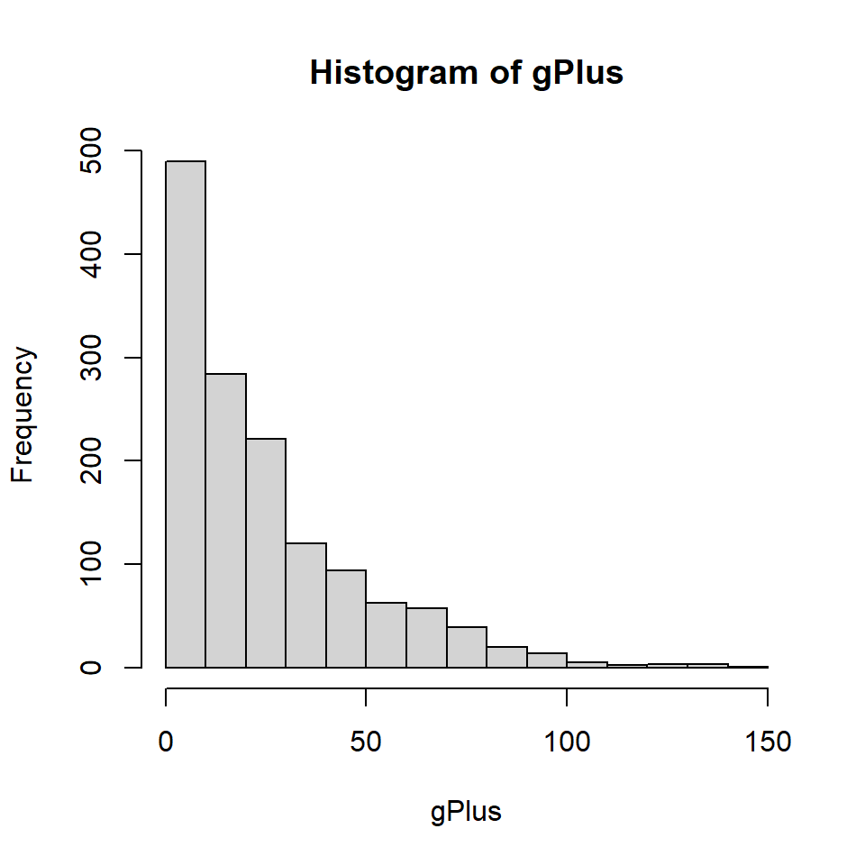

Table 3: MSA: Guttman errors for all item set

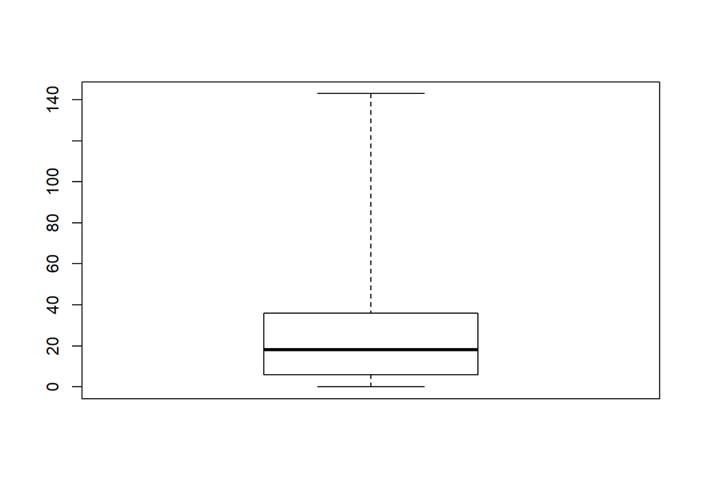

```r
# Adjusted Boxplot for Skew Distributions
adjgPlus <- robustbase::adjbox(gPlus)
```

```r
outlier_adj <- gPlus > adjgPlus$fence[2]
```

```
## $Hij
##        ebas_1  se      ebas_2  se      ebas_3  se      ebas_4  se      ebas_5
## ebas_1                  0.373  (0.026)  0.355  (0.025)  0.354  (0.026)  0.360
## ebas_2  0.373  (0.026)                  0.455  (0.024)  0.476  (0.023)  0.550
## ebas_3  0.355  (0.025)  0.455  (0.024)                  0.871  (0.009)  0.738
## ebas_4  0.354  (0.026)  0.476  (0.023)  0.871  (0.009)                  0.776
## ebas_5  0.360  (0.025)  0.550  (0.021)  0.738  (0.016)  0.776  (0.014)
## ebas_6  0.398  (0.025)  0.479  (0.023)  0.814  (0.012)  0.811  (0.013)  0.752
##        se      ebas_6  se
## ebas_1 (0.025)  0.398  (0.025)
## ebas_2 (0.021)  0.479  (0.023)
## ebas_3 (0.016)  0.814  (0.012)
## ebas_4 (0.014)  0.811  (0.013)
## ebas_5          0.752  (0.015)
## ebas_6 (0.015)
##
## $Hi
##        Item H  se
## ebas_1   0.368 (0.021)
## ebas_2   0.468 (0.018)
## ebas_3   0.664 (0.011)
## ebas_4   0.674 (0.011)
## ebas_5   0.647 (0.012)
## ebas_6   0.665 (0.011)
##
## $H
## Scale H      se
##   0.588 (0.012)
```

Table 1: MSA: Homogeneity values (and standard errors) for items

|  | Item H | se |
| --- | --- | --- |
| ebas_1 | 0.368 | (0.021) |
| ebas_2 | 0.468 | (0.018) |
| ebas_3 | 0.664 | (0.011) |
| ebas_4 | 0.674 | (0.011) |
| ebas_5 | 0.647 | (0.012) |
| ebas_6 | 0.665 | (0.011) |

The complete item set has a homogeneity value H(se) = 0.588, (0.012).

Table 2: MSA: *aisp* for increasing H thresholds (c)

| Item | 0.05 | 0.10 | 0.15 | 0.20 | 0.25 | 0.30 | 0.35 | 0.40 | 0.45 | 0.50 | 0.55 | 0.60 | 0.65 | 0.70 | 0.75 | 0.80 |
| --- | --- | --- | --- | --- | --- | --- | --- | --- | --- | --- | --- | --- | --- | --- | --- | --- |
| ebas_1 | 1 | 1 | 1 | 1 | 1 | 1 | 1 | 0 | 0 | 0 | 0 | 0 | 0 | 0 | 0 | 0 |
| ebas_2 | 1 | 1 | 1 | 1 | 1 | 1 | 1 | 1 | 1 | 0 | 0 | 0 | 0 | 0 | 0 | 0 |
| ebas_3 | 1 | 1 | 1 | 1 | 1 | 1 | 1 | 1 | 1 | 1 | 1 | 1 | 1 | 1 | 1 | 1 |
| ebas_4 | 1 | 1 | 1 | 1 | 1 | 1 | 1 | 1 | 1 | 1 | 1 | 1 | 1 | 1 | 1 | 1 |
| ebas_5 | 1 | 1 | 1 | 1 | 1 | 1 | 1 | 1 | 1 | 1 | 1 | 1 | 1 | 1 | 1 | 0 |
| ebas_6 | 1 | 1 | 1 | 1 | 1 | 1 | 1 | 1 | 1 | 1 | 1 | 1 | 1 | 1 | 1 | 1 |

A selection of the items to investigate further (one scale or more subscales) can be performed by selecting a solution from the table above, or by selecting specific items in connection with theoretical considerations; most importantly, the items selected should show unidimensionality at a threshold level of .30 or higher.

### Subscale 1:

```
## $Hij
##        ebas_1  se      ebas_2  se
## ebas_1                  0.373  (0.026)
## ebas_2  0.373  (0.026)
##
## $Hi
##        Item H  se
## ebas_1   0.373 (0.026)
## ebas_2   0.373 (0.026)
##
## $H
## Scale H      se
##   0.373 (0.026)
```

**Local independence** for the subscale 1 items is presented below as TRUE/FALSE values:

TRUE, TRUE

**Monotonicity** tests are shown in Table 5 for default minsize (alternative values of 60 and 50 are displayed below as R output). Item step response functions (minsize=50) are displayed visually in Figure 2

Table 5: MSA: Subcale 1: monotonicity with default minsize

|  | ItemH | #ac | #vi | #vi/#ac | maxvi | sum | sum/#ac | zmax | #zsig | crit |
| --- | --- | --- | --- | --- | --- | --- | --- | --- | --- | --- |
| ebas_1 | 0.37 | 90 | 2 | 0.02 | 0.05 | 0.10 | 0.0011 | 1.66 | 1 | 29 |
| ebas_2 | 0.37 | 90 | 1 | 0.01 | 0.03 | 0.03 | 0.0004 | 0.94 | 0 | 8 |

```
##        ItemH #ac #vi #vi/#ac maxvi  sum sum/#ac zmax #zsig crit
## ebas_1  0.37 126   6    0.05  0.09 0.40  0.0032 1.66     1   40
## ebas_2  0.37 126   1    0.01  0.04 0.04  0.0003 0.95     0    9
```

```
##        ItemH #ac #vi #vi/#ac maxvi  sum sum/#ac zmax #zsig crit
## ebas_1  0.37 126   6    0.05  0.09 0.40  0.0032 1.66     1   40
## ebas_2  0.37 126   1    0.01  0.04 0.04  0.0003 0.95     0    9
```

[figure not shown]

Figure 2: MSA: Subcale 1: ISRF with minsize=50

# Step 4: Factor analysis

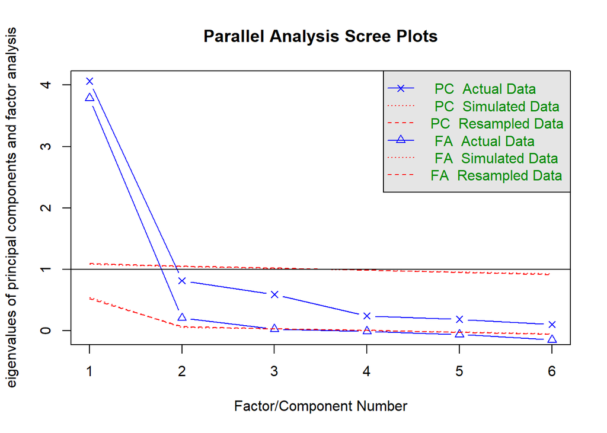

```
## Parallel analysis suggests that the number of factors =  2  and the number of components =  1
```

```r
# consider using tetrachoric correlations for binary items (cor="tet"), and polychoric for ordinal items (cor="poly"); Pearson correlations are specified below (default)
fa.parallel(ebas , cor="poly"
            )
```